# Alports Glom EC Analysis

Jonathan Nelson

09 December, 2025

# 1 Load Packages

```r
if (!require("knitr")) {install.packages("knitr"); require("knitr")}
if (!requireNamespace('BiocManager', quietly = TRUE)) {install.packages('BiocManager'); require("BiocManager")}
if (!require("dplyr")) {install.packages("dplyr"); require("dplyr")}
if (!require("stringr")) {install.packages("stringr"); require("stringr")}
if (!require("Seurat")) {install.packages("Seurat"); require("Seurat")}
if (!require("sctransform")) {install.packages("sctransform"); require("sctransform")}
if (!require("glmGamPoi")) {BiocManager::install('glmGamPoi'); require("glmGamPoi")}
if (!require("patchwork")) {install.packages("patchwork"); require("patchwork")}
if (!require("ggplot2")) {install.packages("ggplot2"); require("ggplot2")}
if (!require("EnhancedVolcano")) {BiocManager::install('EnhancedVolcano'); require("EnhancedVolcano")}
if (!require("DESeq2")) {BiocManager::install('DESeq2'); require("DESeq2")}
if (!require("tidyverse")) {install.packages("tidyverse"); require("tidyverse")}
if (!require("RColorBrewer")) {install.packages("RColorBrewer"); require("RColorBrewer")}
if (!require("car")) {install.packages("car"); require("car")}
if (!require("openxlsx")) {install.packages("openxlsx"); require("openxlsx")}
if (!require("readxl")) {install.packages("readxl"); require("readxl")}
if (!require("ggrepel")) {install.packages("ggrepel"); require("ggrepel")}
if (!require("gghighlight")) {install.packages("gghighlight"); require("gghighlight")}
if (!require("ggpmisc")) {install.packages("ggpmisc"); require("ggpmisc")}
if (!require("data.table")) {install.packages("data.table"); require("data.table")}
if (!require("here")) {install.packages("here"); require("here")}
if (!require("clusterProfiler")) {BiocManager::install('clusterProfiler'); require("clusterProfiler")}
if (!require("enrichplot")) {BiocManager::install('enrichplot'); require("enrichplot")}
if (!require("tidyverse")) {install.packages("tidyverse"); require("tidyverse")} # for data frame transformation
if (!require("gplots")) {install.packages("gplots"); require("gplots")}
if (!require("ggvenn")) {install.packages("ggvenn"); require("ggvenn")}
if (!require("ggrepel")) {install.packages("ggrepel"); require("ggrepel")}

library("EnhancedVolcano")
library(UpSetR)
library(ComplexHeatmap)
#install.packages("ggtext")
library(ggtext)
library(kableExtra)


options(future.globals.maxSize = 74 * 1024^3) # 55 GB
getOption("future.globals.maxSize") #59055800320
```

```
## [1] 79456894976
```

```r
here()
```

```
## [1] "F:/KRC Datasets/Sargis/alport_gloms"
```

# 2 Introduction

## 2.1 Email from Sargis on 11/3/2025

Q1: The color codes assigned to GEC subtypes in the heatmap do not match those used in the bar graphs showing subtype frequences. I was able to classify the subtypes based on the top 5 markers in the heatmap but was not able to compare between the groups due to this issue.

Q2: EC subtype classification: Please, let me know what you think about it.

Q3: Could you please help me identify the genes in these Venn diagrams, (also including the comparison between 1EV/AS vs 4M/WT) especially those overlapping. I tried to extract them from the excel files using different cut offs, but I kept getting different numbers than yours. Could not figure out why. And then it would be interesting to do pathway analysis (or GO analysis) on these sets of genes for each Venn diagram.

Q4: Would it be possible to have a pseudobulk PCA analysis of the groups? like for examples WT, 4M, 1EV and 2EV in one PCA plot, and separately WT, 4M AS and 6m AS in a different PCA plot?

```r
SO <- readRDS(file = here("outputs", "Alports_Glom_EC.rds"))

# DimPlot(SO, label = T)
```

# 3 Q1

### 3.0.1 Creating a Consistent Color Palette v1

```r
library(scales)   # ggplot2 depends on this

# ggplot2 default discrete palette (6 colors)
my_colors <- scales::hue_pal()(7)

# my_colors

type_levels <- c(
  "Type_A",
  "Type_B",
  "Type_C",
  "Type_D",
  "Type_E",
  "Type_Mito",
  "Type_Prolif"
)

names(my_colors) <- type_levels
#my_colors
```

```r
SO <- PrepSCTFindMarkers(SO)

SO.markers <- FindAllMarkers(SO, only.pos = TRUE, min.pct = .25)

SO.markers %>%
    group_by(cluster) %>%
    dplyr::filter(avg_log2FC > 1) %>%
    slice_head(n = 5) %>%
    ungroup() -> top10

# DoHeatmap(SO, features = top10$gene) + NoLegend()
```

## 3.1 Rename v1

```r
SO2 <- SO

SO2@meta.data <- SO2@meta.data %>%
  mutate(subclass_EC = dplyr::case_when(
    seurat_clusters == 0  ~ "Type_A",
    seurat_clusters == 1  ~ "Type_A",
    seurat_clusters == 2  ~ "Type_B",
    seurat_clusters == 3  ~ "Type_B",
    seurat_clusters == 4  ~ "Type_C",
    seurat_clusters == 5  ~ "Type_D",
    seurat_clusters == 6  ~ "Type_Mito",
    seurat_clusters == 7  ~ "Type_D",
    seurat_clusters == 8  ~ "Type_E",
    seurat_clusters == 9  ~ "Type_Prolif"
  ))

SO2@meta.data$subclass_EC <- factor(
  SO2@meta.data$subclass_EC,
  levels = c(
    "Type_A",
    "Type_B",
    "Type_C",
    "Type_D",
    "Type_E",
    "Type_Mito",
    "Type_Prolif"
  )
)
```

### 3.1.1 Creating a Consistent Color Palette v1

```r
library(scales)   # ggplot2 depends on this

# ggplot2 default discrete palette (6 colors)
my_colors <- scales::hue_pal()(7)

# my_colors

type_levels <- c(
  "Type_A",
  "Type_B",
  "Type_C",
  "Type_D",
  "Type_E",
  "Type_Mito",
  "Type_Prolif"
)

names(my_colors) <- type_levels
#my_colors
```

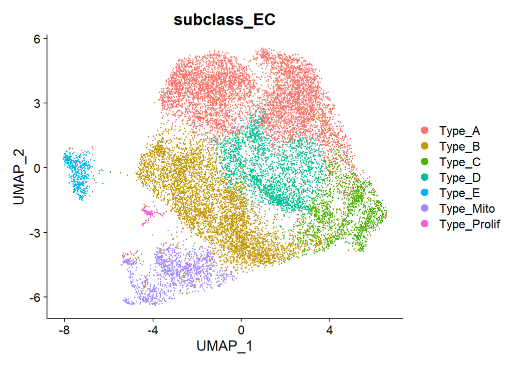

```r
DimPlot(SO2, group.by = "subclass_EC",) + scale_color_manual(values = my_colors)
```

## 3.2 Rename v2

### 3.2.1 Creating a Consistent Color Palette v2

```r
library(scales)   # ggplot2 depends on this

# ggplot2 default discrete palette (6 colors)
my_colors2 <- scales::hue_pal()(7)

# my_colors

type_levels <- c(
  "Type_1",
  "Type_2",
  "Type_3",
  "Type_4",
  "Type_5",
  "Type_6",
  "Type_7"
)

names(my_colors2) <- type_levels
my_colors2
```

```
##    Type_1    Type_2    Type_3    Type_4    Type_5    Type_6    Type_7
## "#F8766D" "#C49A00" "#53B400" "#00C094" "#00B6EB" "#A58AFF" "#FB61D7"
```

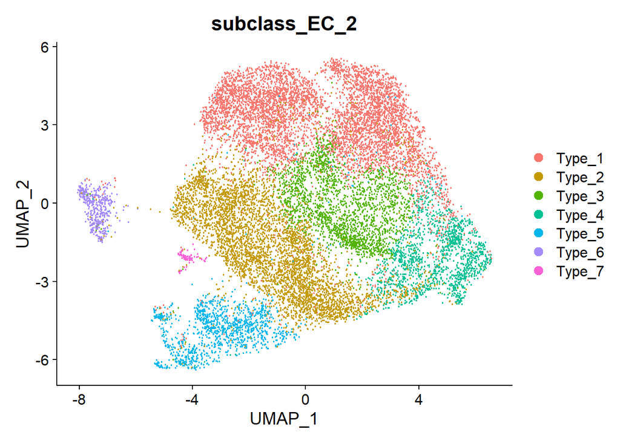

```r
SO2@meta.data <- SO2@meta.data %>%
  mutate(subclass_EC_2 = dplyr::case_when(
    subclass_EC == "Type_A"  ~ "Type_1",
    subclass_EC == "Type_B"  ~ "Type_2",
    subclass_EC == "Type_C"  ~ "Type_4",
    subclass_EC == "Type_D"  ~ "Type_3",
    subclass_EC == "Type_E" ~ "Type_6",
    subclass_EC == "Type_Mito"  ~ "Type_5",
    subclass_EC == "Type_Prolif"  ~ "Type_7"
  ))

SO2@meta.data$subclass_EC_2 <- factor(
  SO2@meta.data$subclass_EC_2,
  levels = c(
    "Type_1",
    "Type_2",
    "Type_3",
    "Type_4",
    "Type_5",
    "Type_6",
    "Type_7"
  )
)

DimPlot(SO2, group.by = "subclass_EC_2") + scale_color_manual(values = my_colors2)
```

## 3.3 Table of EC Cell Type Identities

**Cell Clusters with Marker Genes and Cell States**

| Cluster | Markers | Cell_State |
| --- | --- | --- |
| Type_1 | Csrnp1, Nfkbiz, Ppp1r10, Socs1, Dusp5 | Immune-regulatory |
| Type_2 | Ddnrb, Fabp4, Gda, Akap12, Pde7b | Lipid, structural maintenance, quiescent |
| Type_3 | Slc6a6, Pltp, Atp13a3, Aqp1, Slc26a10 | Transport-focused |
| Type_4 | Slc45a4, Gja5, Esm1, Cxcr4, Hey1 | Angiogenic |
| Type_5 | mt-Nd5, mt-Nd4, mt-Nd3, mt-Nd2, mt-Nd4l | Mitochondrial-rich |
| Type_6 | Dlk1, Rtl1, Sez6l2, Egln3 | Developmental |
| Type_7 | Uhrf1, Gins2, Mki67, Fignl1, Rad51 | Proliferative |

## 3.4 Heatmap

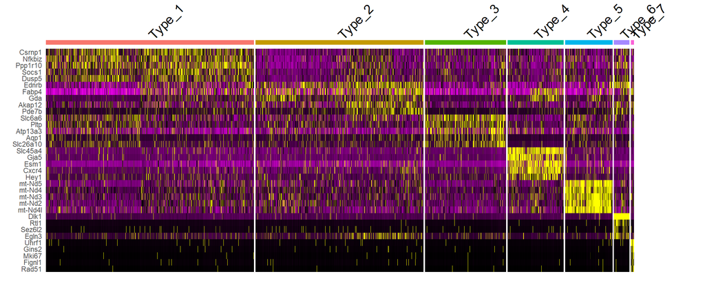

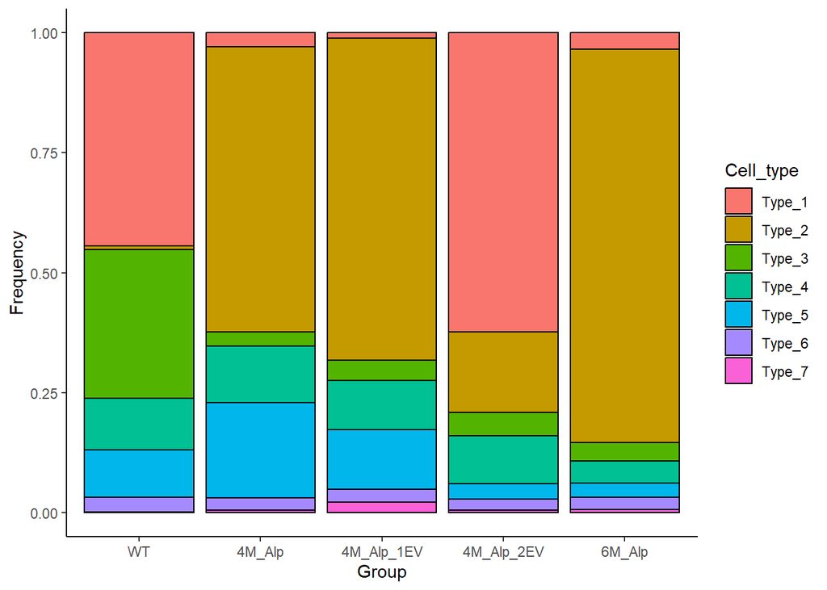

```r
t1 <- table(SO2@meta.data$subclass_EC_2, SO2$group)[, c("WT", "4M_Alp", "4M_Alp_1EV", "4M_Alp_2EV", "6M_Alp")]
#t1

prop.t1 <- prop.table(t1, margin = 2)
#prop.t1

t2 <- as.data.frame(t1)
colnames(t2) <- c('Cell_type', 'Group', 'Frequency')

# Original plot

ggplot(t2, aes(fill=Cell_type, y=Frequency, x=Group)) +
  geom_bar(position="fill", stat = "identity", fun.y = "mean", colour="black") +
  scale_fill_manual(values = my_colors2) +
  theme_classic()
```

# 4 Q2

Seems good to me and see above for changing the names of the EC clusters and creating a consistnent color palette.

# 5 Q3

## 5.1 The Problem

Part of the problem you were facing in trying to **compare the Venn Diagrams and the CSV DEG lists** were created in different ways and from different files at different points in the analysis.

DEG lists:

From **Alports_Quantify_Number_of_DEGs_WTv4M_Alp_1EV_09182025**

Using **SCT** assay and **Seurat_5.3.0**

for (i in clusters) { DefaultAssay(SO) <- “SCT” DEGs <- FindMarkers(SO, ident.1 = “4M_Alp_1EV”, ident.2 = “WT”, group.by = “group” , subset.ident = i, logfc.threshold = .1, min.pct = .1) DEGs <- DEGs %>% rownames_to_column(“gene”) %>% filter(p_val_adj < .05) DEGs <- DEGs[order(DEGs[,“avg_log2FC”], decreasing = TRUE),] assign(paste0(“Alports_4M_”,names(clusters[i])), DEGs, envir = DEG.env)

Venn Diagram: **Alports_subset_ECs_Quantify_Reversal_Genes_0528202**

I think using **RNA** assay and **Seurat_4.4.0**

df1 <- FindMarkers(SO_EC_Clean, ident.1 = Condition_A, ident.2 = Condition_Baseline, group.by = “group”, subset.ident = “EC_glom”, logfc.threshold = 0.1, min.pct = 0.1)

## 5.2 The Solution

Start with the DEG lists from **Alports_Quantify_Number_of_DEGs_WTv4M_Alp_1EV_09182025** and create Venn Diagrams and new intersection lists to perform Pathways Analysis.

## 5.3 Update: **Solution Didn’t work**

### 5.3.1 The Previous DEG lists aren’t the correct comparisons for making the Venn Diagrams

### 5.3.2 They were really setup to look at all the different populations…not just ECs

### 5.3.3 Solution #2

Recreate the DEG lists again from the **Alports_Glom_EC.rds** dataset and save them as csv files as well.

### 5.3.4 Re-create DEG Lists

df1 <- FindMarkers(SO_EC_Clean, ident.1 = Condition_A, ident.2 = Condition_Baseline, group.by = “group”, subset.ident = “EC_glom”, logfc.threshold = 0.1, min.pct = 0.1)

df2 <- FindMarkers(SO_EC_Clean, ident.1 = Condition_B, ident.2 = Condition_A, group.by = “group”, subset.ident = “EC_glom”, logfc.threshold = 0.1, min.pct = 0.1)

df3 <- FindMarkers(SO_EC_Clean, ident.1 = Condition_C, ident.2 = Condition_A, group.by = “group”, subset.ident = “EC_glom”, logfc.threshold = 0.1, min.pct = 0.1)

df4 <- FindMarkers(SO_EC_Clean, ident.1 = Condition_D, ident.2 = Condition_A, group.by = “group”, subset.ident = “EC_glom”, logfc.threshold = 0.1, min.pct = 0.1)

#### 5.3.4.1 DEG Setup

```r
Condition_Baseline <- "WT"

Condition_A <- "4M_Alp"

Condition_B <- "4M_Alp_1EV"

Condition_C <- "4M_Alp_2EV"

Condition_D <- "6M_Alp"

clusters <- unique(SO2@meta.data$class_merge)
names(clusters) <- clusters

SO <- PrepSCTFindMarkers(SO2)
DEG.env <- new.env()

Idents(SO2) <- SO2@meta.data$group

DefaultAssay(SO2) <- "SCT"
```

#### 5.3.4.2 df1

4M_Alp vs. WT

```r
DEGs <- FindMarkers(SO2, ident.1 = Condition_A, ident.2 = Condition_Baseline, logfc.threshold = .1, min.pct = .1)
DEGs <- DEGs %>% rownames_to_column("gene") %>% filter(p_val_adj < .05)
DEGs <- DEGs[order(DEGs[,"avg_log2FC"], decreasing = TRUE),]

#remove the first column of from the dataframe DEGs
DEGs <- rownames_to_column(DEGs)
DEGs <- DEGs[,-1]

df <- head(DEGs, 20)

df
```

|  | gene | p_val | avg_log2FC | pct.1 | pct.2 | p_val_adj |
| --- | --- | --- | --- | --- | --- | --- |
| 1 | Fkbp5 | 0.000000e+00 | 4.433074 | 0.807 | 0.083 | 0.000000e+00 |
| 2 | Gda | 0.000000e+00 | 3.887379 | 0.654 | 0.079 | 0.000000e+00 |
| 3 | Itgb3 | 0.000000e+00 | 3.683221 | 0.546 | 0.067 | 0.000000e+00 |
| 4 | Cd36 | 1.922499e-189 | 3.021699 | 0.297 | 0.057 | 2.678234e-185 |
| 5 | Nt5e | 6.835859e-139 | 2.787392 | 0.207 | 0.034 | 9.523036e-135 |
| 6 | Serpina3g | 6.708544e-284 | 2.727227 | 0.433 | 0.085 | 9.345672e-280 |
| 7 | Shroom3 | 1.666787e-90 | 2.441839 | 0.147 | 0.027 | 2.322001e-86 |
| 8 | Fabp4 | 0.000000e+00 | 2.390893 | 0.781 | 0.393 | 0.000000e+00 |
| 9 | Ifit3 | 5.292844e-132 | 2.323687 | 0.298 | 0.085 | 7.373461e-128 |
| 10 | Ifit3b | 1.347350e-77 | 2.262968 | 0.152 | 0.035 | 1.876993e-73 |

[output cut: 10 more lines]

```r
df1 <- DEGs
```

#### 5.3.4.3 df2

4M_Alp_1EV vs. 4M_Alp

```r
DEGs <- FindMarkers(SO2, ident.1 = Condition_B, ident.2 = Condition_A, logfc.threshold = .1, min.pct = .1)
DEGs <- DEGs %>% rownames_to_column("gene") %>% filter(p_val_adj < .05)
DEGs <- DEGs[order(DEGs[,"avg_log2FC"], decreasing = TRUE),]

#remove the first column of from the dataframe DEGs
DEGs <- rownames_to_column(DEGs)
DEGs <- DEGs[,-1]

df <- head(DEGs, 20)

df
```

|  | gene | p_val | avg_log2FC | pct.1 | pct.2 | p_val_adj |
| --- | --- | --- | --- | --- | --- | --- |
| 1 | 8430408G22Rik | 1.694614e-07 | 1.0839545 | 0.258 | 0.179 | 2.360767e-03 |
| 2 | Rbm3 | 1.164055e-24 | 1.0537434 | 0.404 | 0.228 | 1.621645e-20 |
| 3 | H2-Q6 | 2.430250e-34 | 1.0429118 | 0.563 | 0.355 | 3.385582e-30 |
| 4 | Hsph1 | 1.660214e-32 | 0.9298510 | 0.511 | 0.281 | 2.312844e-28 |
| 5 | Ddit4 | 2.450712e-17 | 0.8680380 | 0.412 | 0.260 | 3.414087e-13 |
| 6 | Per1 | 8.901101e-48 | 0.7866106 | 0.866 | 0.726 | 1.240012e-43 |
| 7 | Kctd12b | 6.124047e-24 | 0.7539917 | 0.771 | 0.659 | 8.531410e-20 |
| 8 | Ednrb | 2.399113e-34 | 0.7412397 | 0.894 | 0.768 | 3.342204e-30 |
| 9 | Gcnt1 | 4.415697e-09 | 0.7320865 | 0.306 | 0.208 | 6.151507e-05 |
| 10 | Cacybp | 2.530853e-12 | 0.7259021 | 0.381 | 0.257 | 3.525732e-08 |

[output cut: 10 more lines]

```r
df2 <- DEGs
```

#### 5.3.4.4 df3

4M_Alp_2EV vs. 4M_Alp

```r
DEGs <- FindMarkers(SO2, ident.1 = Condition_C, ident.2 = Condition_A, logfc.threshold = .1, min.pct = .1)
DEGs <- DEGs %>% rownames_to_column("gene") %>% filter(p_val_adj < .05)
DEGs <- DEGs[order(DEGs[,"avg_log2FC"], decreasing = TRUE),]

#remove the first column of from the dataframe DEGs
DEGs <- rownames_to_column(DEGs)
DEGs <- DEGs[,-1]

df <- head(DEGs, 20)

df
```

|  | gene | p_val | avg_log2FC | pct.1 | pct.2 | p_val_adj |
| --- | --- | --- | --- | --- | --- | --- |
| 1 | Cxcl10 | 1.387448e-71 | 4.994705 | 0.165 | 0.011 | 1.932854e-67 |
| 2 | Tex29 | 7.838479e-48 | 3.795002 | 0.114 | 0.008 | 1.091979e-43 |
| 3 | Muc13 | 4.469413e-66 | 3.424522 | 0.166 | 0.017 | 6.226339e-62 |
| 4 | Adamts4 | 1.127952e-37 | 3.174878 | 0.125 | 0.026 | 1.571350e-33 |
| 5 | Fosl1 | 1.184708e-37 | 3.167914 | 0.101 | 0.012 | 1.650416e-33 |
| 6 | Nabp1 | 3.309961e-156 | 2.946658 | 0.403 | 0.082 | 4.611106e-152 |
| 7 | Prkcg | 5.742723e-55 | 2.913656 | 0.158 | 0.025 | 8.000187e-51 |
| 8 | Lag3 | 1.123456e-55 | 2.864094 | 0.161 | 0.025 | 1.565086e-51 |
| 9 | Csrnp1 | 0.000000e+00 | 2.633402 | 0.761 | 0.264 | 0.000000e+00 |
| 10 | Irf1 | 0.000000e+00 | 2.605205 | 0.934 | 0.664 | 0.000000e+00 |

[output cut: 10 more lines]

```r
df3 <- DEGs
```

#### 5.3.4.5 df4

6M_Alp vs. 4M_Alp

```r
DEGs <- FindMarkers(SO2, ident.1 = Condition_D, ident.2 = Condition_A, logfc.threshold = .1, min.pct = .1)
DEGs <- DEGs %>% rownames_to_column("gene") %>% filter(p_val_adj < .05)
DEGs <- DEGs[order(DEGs[,"avg_log2FC"], decreasing = TRUE),]

#remove the first column of from the dataframe DEGs
DEGs <- rownames_to_column(DEGs)
DEGs <- DEGs[,-1]

df <- head(DEGs, 20)

df
```

|  | gene | p_val | avg_log2FC | pct.1 | pct.2 | p_val_adj |
| --- | --- | --- | --- | --- | --- | --- |
| 1 | Kcnk5 | 1.633677e-80 | 2.561197 | 0.279 | 0.062 | 2.275875e-76 |
| 2 | Egln3 | 5.111067e-115 | 2.255925 | 0.412 | 0.113 | 7.120227e-111 |
| 3 | Hsph1 | 1.097341e-308 | 2.244390 | 0.800 | 0.281 | 1.528705e-304 |
| 4 | Hsp90aa1 | 1.156011e-304 | 1.898866 | 0.870 | 0.421 | 1.610438e-300 |
| 5 | Apol8 | 3.808577e-26 | 1.857622 | 0.111 | 0.028 | 5.305729e-22 |
| 6 | Atf4 | 6.091778e-115 | 1.813993 | 0.500 | 0.187 | 8.486456e-111 |
| 7 | Egr1 | 0.000000e+00 | 1.803242 | 0.990 | 0.708 | 0.000000e+00 |
| 8 | Rasd1 | 1.973489e-44 | 1.782901 | 0.255 | 0.095 | 2.749268e-40 |
| 9 | Ier5l | 1.237415e-171 | 1.773711 | 0.691 | 0.318 | 1.723842e-167 |
| 10 | Hspa1a | 0.000000e+00 | 1.764959 | 0.982 | 0.805 | 0.000000e+00 |

[output cut: 10 more lines]

```r
df4 <- DEGs
```

#### 5.3.4.6 Filter and Split Positive and Negative Lists

```r
df1_pos <- df1 %>% filter(avg_log2FC > 0) %>% filter(p_val_adj < 0.05) %>% arrange(desc(abs(avg_log2FC)))

df1_pos
```

| gene | p_val | avg_log2FC | pct.1 | pct.2 | p_val_adj |
| --- | --- | --- | --- | --- | --- |
| Fkbp5 | 0.000000e+00 | 4.4330737 | 0.807 | 0.083 | 0.000000e+00 |
| Gda | 0.000000e+00 | 3.8873794 | 0.654 | 0.079 | 0.000000e+00 |
| Itgb3 | 0.000000e+00 | 3.6832209 | 0.546 | 0.067 | 0.000000e+00 |
| Cd36 | 1.922499e-189 | 3.0216992 | 0.297 | 0.057 | 2.678234e-185 |
| Nt5e | 6.835859e-139 | 2.7873917 | 0.207 | 0.034 | 9.523036e-135 |
| Serpina3g | 6.708544e-284 | 2.7272275 | 0.433 | 0.085 | 9.345672e-280 |
| Shroom3 | 1.666787e-90 | 2.4418388 | 0.147 | 0.027 | 2.322001e-86 |
| Fabp4 | 0.000000e+00 | 2.3908931 | 0.781 | 0.393 | 0.000000e+00 |
| Ifit3 | 5.292844e-132 | 2.3236866 | 0.298 | 0.085 | 7.373461e-128 |
| Ifit3b | 1.347350e-77 | 2.2629685 | 0.152 | 0.035 | 1.876993e-73 |

[output cut: 5773 more lines]

```r
df1_neg <- df1 %>% filter(avg_log2FC < 0) %>% filter(p_val_adj < 0.05) %>% arrange(desc(abs(avg_log2FC)))

df1_neg
```

| gene | p_val | avg_log2FC | pct.1 | pct.2 | p_val_adj |
| --- | --- | --- | --- | --- | --- |
| Lag3 | 3.529094e-50 | -2.9463087 | 0.025 | 0.148 | 4.916381e-46 |
| Mgst1 | 6.150090e-39 | -2.7094121 | 0.019 | 0.116 | 8.567690e-35 |
| Gadd45b | 0.000000e+00 | -2.6971850 | 0.289 | 0.730 | 0.000000e+00 |
| Atf3 | 0.000000e+00 | -2.4972454 | 0.448 | 0.925 | 0.000000e+00 |
| Arc | 1.284257e-145 | -2.4758032 | 0.155 | 0.462 | 1.789098e-141 |
| Fosb | 0.000000e+00 | -2.4104654 | 0.650 | 0.984 | 0.000000e+00 |
| Ier5l | 5.999815e-306 | -2.4001904 | 0.318 | 0.724 | 8.358342e-302 |
| Ier3 | 0.000000e+00 | -2.3806546 | 0.490 | 0.924 | 0.000000e+00 |
| Fos | 0.000000e+00 | -2.2774306 | 0.754 | 0.994 | 0.000000e+00 |
| Dnajb1 | 0.000000e+00 | -2.2692826 | 0.505 | 0.882 | 0.000000e+00 |

[output cut: 338 more lines]

```r
df2_pos <- df2 %>% filter(avg_log2FC > 0) %>% filter(p_val_adj < 0.05) %>% arrange(desc(abs(avg_log2FC)))

df2_pos
```

| gene | p_val | avg_log2FC | pct.1 | pct.2 | p_val_adj |
| --- | --- | --- | --- | --- | --- |
| 8430408G22Rik | 1.694614e-07 | 1.0839545 | 0.258 | 0.179 | 2.360767e-03 |
| Rbm3 | 1.164055e-24 | 1.0537434 | 0.404 | 0.228 | 1.621645e-20 |
| H2-Q6 | 2.430250e-34 | 1.0429118 | 0.563 | 0.355 | 3.385582e-30 |
| Hsph1 | 1.660214e-32 | 0.9298510 | 0.511 | 0.281 | 2.312844e-28 |
| Ddit4 | 2.450712e-17 | 0.8680380 | 0.412 | 0.260 | 3.414087e-13 |
| Per1 | 8.901101e-48 | 0.7866106 | 0.866 | 0.726 | 1.240012e-43 |
| Kctd12b | 6.124047e-24 | 0.7539917 | 0.771 | 0.659 | 8.531410e-20 |
| Ednrb | 2.399113e-34 | 0.7412397 | 0.894 | 0.768 | 3.342204e-30 |
| Gcnt1 | 4.415697e-09 | 0.7320865 | 0.306 | 0.208 | 6.151507e-05 |
| Cacybp | 2.530853e-12 | 0.7259021 | 0.381 | 0.257 | 3.525732e-08 |

[output cut: 86 more lines]

```r
df2_neg <- df2 %>% filter(avg_log2FC < 0) %>% filter(p_val_adj < 0.05) %>% arrange(desc(abs(avg_log2FC)))

df2_neg
```

| gene | p_val | avg_log2FC | pct.1 | pct.2 | p_val_adj |
| --- | --- | --- | --- | --- | --- |
| Hic1 | 1.108301e-20 | -1.7495428 | 0.068 | 0.211 | 1.543973e-16 |
| Gda | 8.387179e-57 | -1.4413649 | 0.364 | 0.654 | 1.168418e-52 |
| Lrg1 | 1.157364e-18 | -1.3055430 | 0.203 | 0.360 | 1.612324e-14 |
| Zfp503 | 1.227355e-16 | -1.1686731 | 0.134 | 0.276 | 1.709828e-12 |
| Itgb3 | 3.852572e-35 | -1.1085215 | 0.305 | 0.546 | 5.367017e-31 |
| Cdkl5 | 2.895096e-27 | -1.0913106 | 0.270 | 0.479 | 4.033158e-23 |
| Mycn | 5.860112e-08 | -1.0155969 | 0.066 | 0.137 | 8.163722e-04 |
| Smad7 | 5.429284e-54 | -1.0116792 | 0.538 | 0.781 | 7.563535e-50 |
| Cyp26b1 | 7.677458e-47 | -1.0078601 | 0.607 | 0.803 | 1.069547e-42 |
| Etfbkmt | 1.434308e-16 | -0.9912636 | 0.190 | 0.345 | 1.998135e-12 |

[output cut: 256 more lines]

```r
df3_pos <- df3 %>% filter(avg_log2FC > 0) %>% filter(p_val_adj < 0.05) %>% arrange(desc(abs(avg_log2FC)))

df3_pos
```

| gene | p_val | avg_log2FC | pct.1 | pct.2 | p_val_adj |
| --- | --- | --- | --- | --- | --- |
| Cxcl10 | 1.387448e-71 | 4.9947053 | 0.165 | 0.011 | 1.932854e-67 |
| Tex29 | 7.838479e-48 | 3.7950023 | 0.114 | 0.008 | 1.091979e-43 |
| Muc13 | 4.469413e-66 | 3.4245225 | 0.166 | 0.017 | 6.226339e-62 |
| Adamts4 | 1.127952e-37 | 3.1748783 | 0.125 | 0.026 | 1.571350e-33 |
| Fosl1 | 1.184708e-37 | 3.1679143 | 0.101 | 0.012 | 1.650416e-33 |
| Nabp1 | 3.309961e-156 | 2.9466581 | 0.403 | 0.082 | 4.611106e-152 |
| Prkcg | 5.742723e-55 | 2.9136561 | 0.158 | 0.025 | 8.000187e-51 |
| Lag3 | 1.123456e-55 | 2.8640937 | 0.161 | 0.025 | 1.565086e-51 |
| Csrnp1 | 0.000000e+00 | 2.6334023 | 0.761 | 0.264 | 0.000000e+00 |
| Irf1 | 0.000000e+00 | 2.6052049 | 0.934 | 0.664 | 0.000000e+00 |

[output cut: 725 more lines]

```r
df3_neg <- df3 %>% filter(avg_log2FC < 0) %>% filter(p_val_adj < 0.05) %>% arrange(desc(abs(avg_log2FC)))

df3_neg
```

| gene | p_val | avg_log2FC | pct.1 | pct.2 | p_val_adj |
| --- | --- | --- | --- | --- | --- |
| Cyp26b1 | 0.000000e+00 | -2.2818602 | 0.338 | 0.803 | 0.000000e+00 |
| mt-Nd5 | 2.250903e-37 | -1.3433960 | 0.473 | 0.571 | 3.135732e-33 |
| mt-Nd4l | 8.202961e-98 | -1.3142249 | 0.632 | 0.773 | 1.142754e-93 |
| Etfbkmt | 2.860399e-59 | -1.2932757 | 0.174 | 0.345 | 3.984822e-55 |
| mt-Nd3 | 2.952383e-61 | -1.1992827 | 0.543 | 0.665 | 4.112965e-57 |
| Gda | 9.099015e-110 | -1.1962328 | 0.407 | 0.654 | 1.267584e-105 |
| mt-Cytb | 2.386157e-69 | -1.1812854 | 0.782 | 0.819 | 3.324155e-65 |
| mt-Co3 | 6.802313e-62 | -1.1622588 | 0.784 | 0.809 | 9.476302e-58 |
| Fam107a | 1.107436e-32 | -1.1581565 | 0.136 | 0.252 | 1.542769e-28 |
| mt-Nd2 | 9.348942e-37 | -1.1181905 | 0.607 | 0.671 | 1.302401e-32 |

[output cut: 1003 more lines]

```r
df4_pos <- df4 %>% filter(avg_log2FC > 0) %>% filter(p_val_adj < 0.05) %>% arrange(desc(abs(avg_log2FC)))

df4_pos
```

| gene | p_val | avg_log2FC | pct.1 | pct.2 | p_val_adj |
| --- | --- | --- | --- | --- | --- |
| Kcnk5 | 1.633677e-80 | 2.5611967 | 0.279 | 0.062 | 2.275875e-76 |
| Egln3 | 5.111067e-115 | 2.2559254 | 0.412 | 0.113 | 7.120227e-111 |
| Hsph1 | 1.097341e-308 | 2.2443895 | 0.800 | 0.281 | 1.528705e-304 |
| Hsp90aa1 | 1.156011e-304 | 1.8988657 | 0.870 | 0.421 | 1.610438e-300 |
| Apol8 | 3.808577e-26 | 1.8576218 | 0.111 | 0.028 | 5.305729e-22 |
| Atf4 | 6.091778e-115 | 1.8139932 | 0.500 | 0.187 | 8.486456e-111 |
| Egr1 | 0.000000e+00 | 1.8032423 | 0.990 | 0.708 | 0.000000e+00 |
| Rasd1 | 1.973489e-44 | 1.7829011 | 0.255 | 0.095 | 2.749268e-40 |
| Ier5l | 1.237415e-171 | 1.7737112 | 0.691 | 0.318 | 1.723842e-167 |
| Hspa1a | 0.000000e+00 | 1.7649592 | 0.982 | 0.805 | 0.000000e+00 |

[output cut: 559 more lines]

```r
df4_neg <- df4 %>% filter(avg_log2FC < 0) %>% filter(p_val_adj < 0.05) %>% arrange(desc(abs(avg_log2FC)))

df4_neg
```

| gene | p_val | avg_log2FC | pct.1 | pct.2 | p_val_adj |
| --- | --- | --- | --- | --- | --- |
| Fam107a | 2.267256e-74 | -2.7541248 | 0.063 | 0.252 | 3.158515e-70 |
| Cd36 | 4.754477e-75 | -2.3525429 | 0.091 | 0.297 | 6.623462e-71 |
| Bcl6 | 5.572126e-45 | -2.3246882 | 0.031 | 0.146 | 7.762529e-41 |
| Cdkl5 | 7.955088e-128 | -2.1427246 | 0.169 | 0.479 | 1.108223e-123 |
| Lrg1 | 3.678198e-63 | -1.8500498 | 0.159 | 0.360 | 5.124098e-59 |
| Ifit3b | 8.420274e-31 | -1.7545210 | 0.051 | 0.152 | 1.173028e-26 |
| Fkbp5 | 1.396970e-229 | -1.7295480 | 0.438 | 0.807 | 1.946119e-225 |
| Gja5 | 4.087450e-11 | -1.7200810 | 0.073 | 0.129 | 5.694226e-07 |
| mt-Nd4l | 2.386661e-128 | -1.6442102 | 0.539 | 0.773 | 3.324857e-124 |
| Fam213a | 5.853065e-78 | -1.5817493 | 0.174 | 0.414 | 8.153905e-74 |

[output cut: 1503 more lines]

## 5.4 Venn Diagram Readout

### 5.4.1 Up -> Down

#### 5.4.1.1 4M vs 4M_1EV

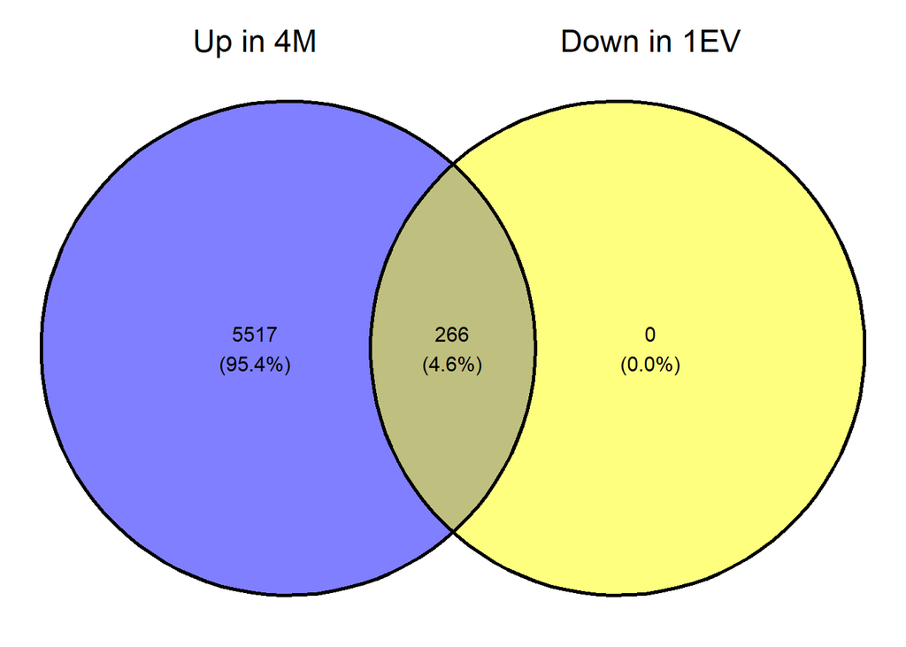

```r
set1 <- rownames(df1_pos)
set2 <- rownames(df2_neg)
venn <- ggvenn(list('Up in 4M' = set1, 'Down in 1EV' = set2))
print(venn)
```

```r
lst <- list(set1, set2)
ItemsList <- venn(lst, show.plot = FALSE)

test <- attributes(ItemsList)$intersections

genelist_4M_Alp_1EV <- test$'A:B'
```

#### 5.4.1.2 4M vs 4M_2EV

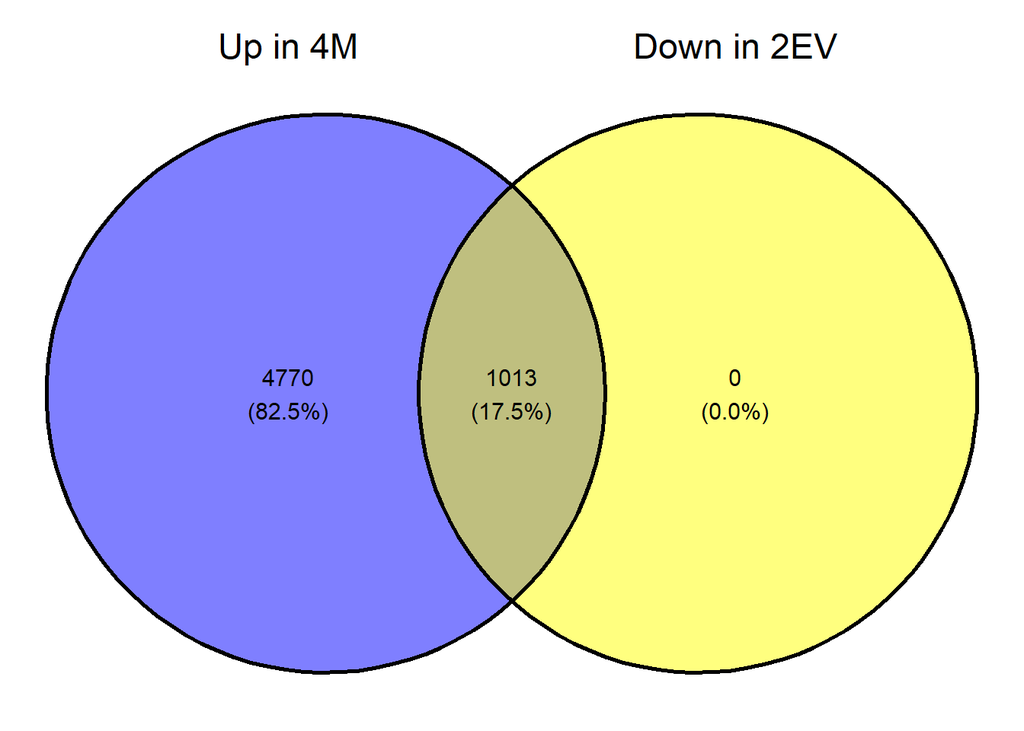

```r
set1 <- rownames(df1_pos)
set2 <- rownames(df3_neg)
venn <- ggvenn(list('Up in 4M' = set1, 'Down in 2EV' = set2))
print(venn)
```

```r
lst <- list(set1, set2)
ItemsList <- venn(lst, show.plot = FALSE)

test <- attributes(ItemsList)$intersections

genelist_4M_Alp_2EV <- test$'A:B'
```

#### 5.4.1.3 4M vs 6M

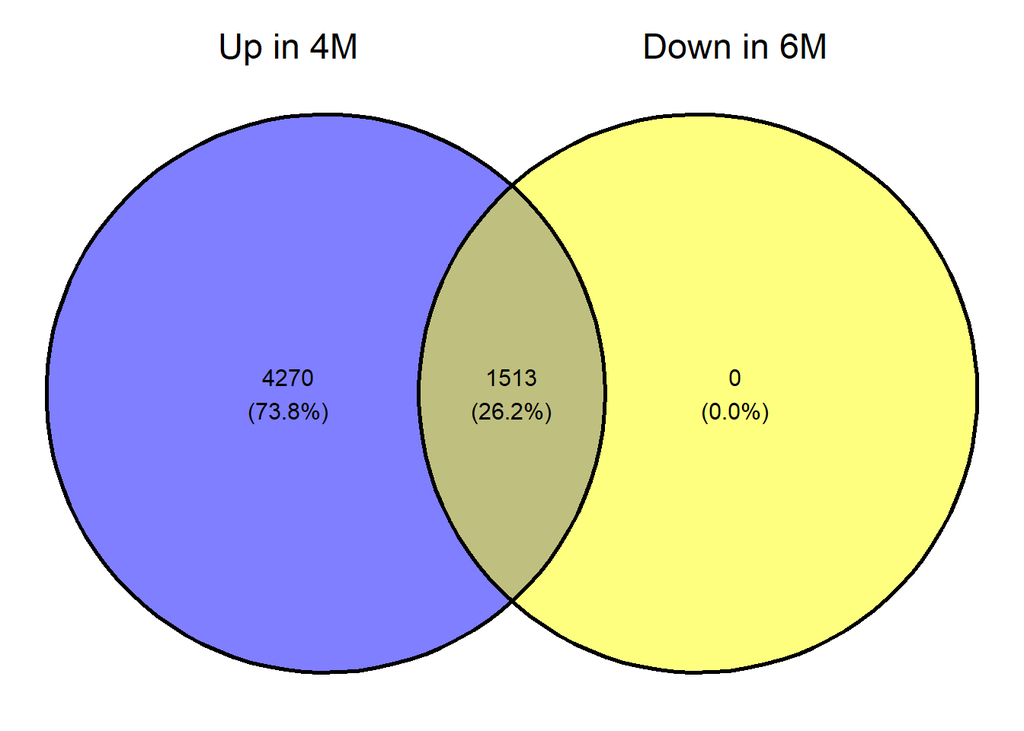

```r
set1 <- rownames(df1_pos)
set2 <- rownames(df4_neg)
venn <- ggvenn(list('Up in 4M' = set1, 'Down in 6M' = set2))
print(venn)
```

```r
lst <- list(set1, set2)
ItemsList <- venn(lst, show.plot = FALSE)

test <- attributes(ItemsList)$intersections

genelist_6M_Alp <- test$'A:B'
```

# 6 Q4

## 6.1 Pseudobulk PCA

### 6.1.1 ALL GROUPS

```r
# head(SO2@meta.data)

pbo <- AggregateExpression(SO2,
                           group.by = "sample",
                           assays = 'RNA',
                           slot = "counts",
                           return.seurat = FALSE)

pbo <- pbo$RNA
# pbo[1:5, 1:5]
colnames(pbo) <- sub("^g", "", colnames(pbo))
# colnames(pbo)[1:5]

# DimPlot(SO2, group.by = "sample")

metadata <- SO2@meta.data %>%
  as.data.frame() %>%
  dplyr::group_by(sample) %>%
  dplyr::summarise(
    Alports = names(sort(table(alports), decreasing = TRUE))[1],  # Most common value
    Batch = names(sort(table(batch), decreasing = TRUE))[1],
    Group = names(sort(table(group), decreasing = TRUE))[1]
  ) %>%
  as.data.frame()

rownames(metadata) <- metadata$sample

# head(metadata)

dds <- DESeqDataSetFromMatrix(countData = round(pbo),
                              colData = metadata,
                              design = ~ sample)

rld <- rlog(dds, blind=TRUE)

sample_names <- unique(rld$sample)
```

#### 6.1.1.1 PCA By **Sample**

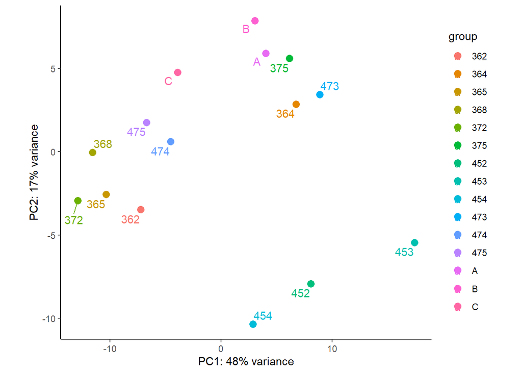

```r
# Plot PCA
sample<-DESeq2::plotPCA(rld, ntop = 1000, intgroup = "sample") +
  geom_text_repel(aes(label = sample_names)) +
  coord_fixed(ratio = 1.5) +
  theme_classic()

plot(sample)
```

#### 6.1.1.2 PCA By **Alports**

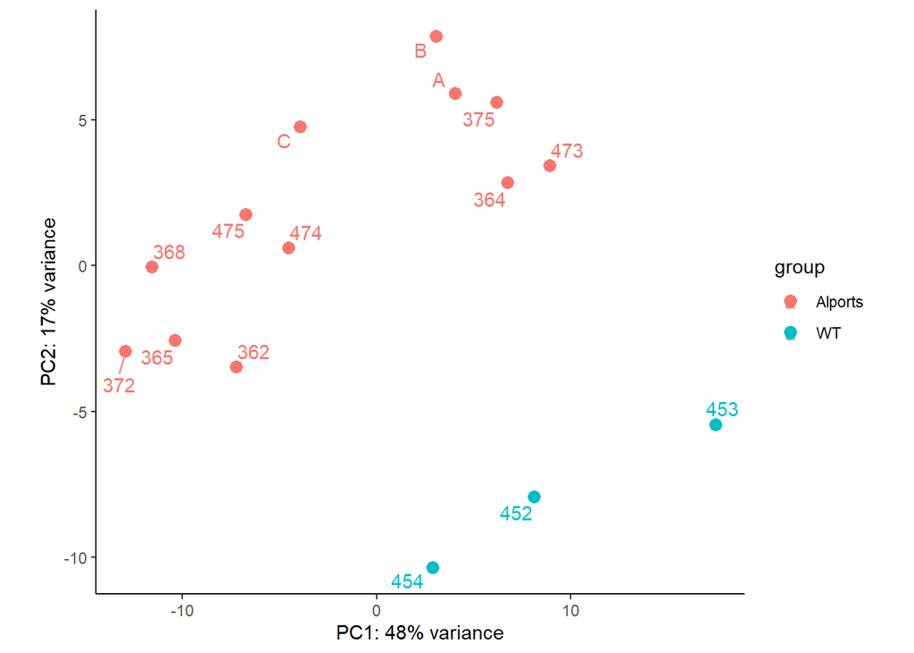

```r
alports <-DESeq2::plotPCA(rld, ntop = 1000, intgroup = "Alports") +
  geom_text_repel(aes(label = sample_names)) +
  coord_fixed(ratio = 1.5) +
  theme_classic()

plot(alports)
```

#### 6.1.1.3 PCA By **Group**

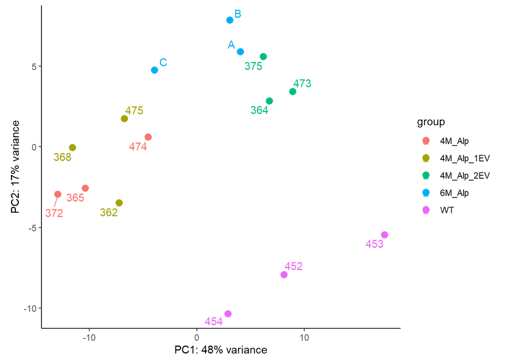

```r
group <-DESeq2::plotPCA(rld, ntop = 1000, intgroup = "Group") +
  geom_text_repel(aes(label = sample_names)) +
  coord_fixed(ratio = 1.5) +
  theme_classic()

plot(group)
```

### 6.1.2 No 6M Alports

```r
# head(SO2@meta.data)

pbo <- AggregateExpression(SO2,
                           group.by = "sample",
                           assays = 'RNA',
                           slot = "counts",
                           return.seurat = FALSE)

pbo <- pbo$RNA
# pbo[1:5, 1:5]
colnames(pbo) <- sub("^g", "", colnames(pbo))
pbo <- pbo[, !colnames(pbo) %in% c("A", "B", "C")]
#colnames(pbo)

# DimPlot(SO2, group.by = "sample")

metadata <- SO2@meta.data %>%
  as.data.frame() %>%
  dplyr::group_by(sample) %>%
  dplyr::summarise(
    Alports = names(sort(table(alports), decreasing = TRUE))[1],  # Most common value
    Batch = names(sort(table(batch), decreasing = TRUE))[1],
    Group = names(sort(table(group), decreasing = TRUE))[1]
  ) %>%
  as.data.frame()

metadata <- metadata %>%
  dplyr::filter(Group != "6M_Alp")

rownames(metadata) <- metadata$sample

# head(metadata)

dds <- DESeqDataSetFromMatrix(countData = round(pbo),
                              colData = metadata,
                              design = ~ sample)

rld <- rlog(dds, blind=TRUE)

sample_names <- unique(rld$sample)
```

#### 6.1.2.1 PCA By **Sample**

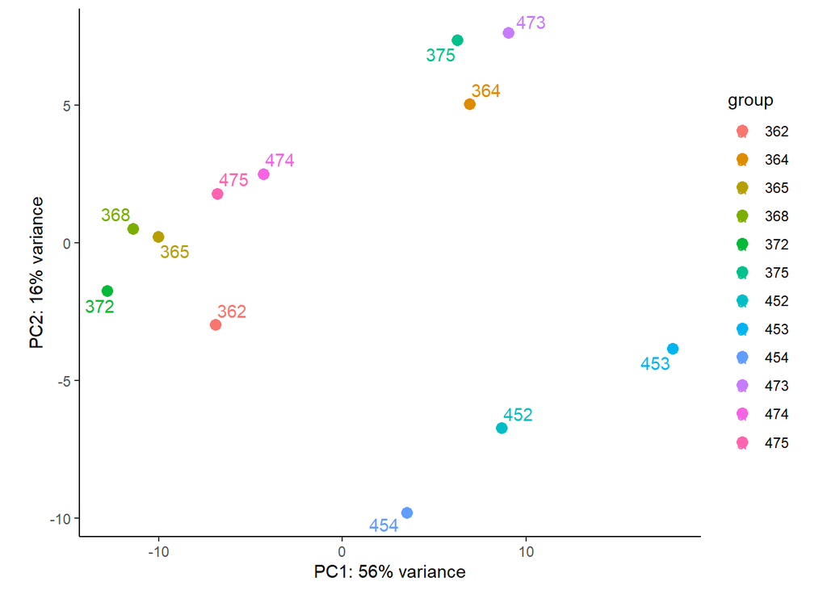

```r
# Plot PCA
sample<-DESeq2::plotPCA(rld, ntop = 1000, intgroup = "sample") +
  geom_text_repel(aes(label = sample_names)) +
  coord_fixed(ratio = 1.5) +
  theme_classic()

plot(sample)
```

#### 6.1.2.2 PCA By **Alports**

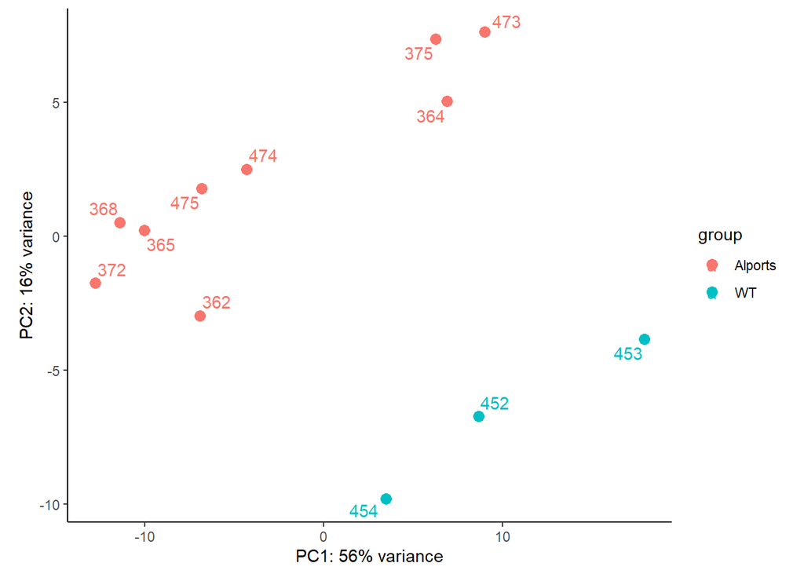

```r
alports <-DESeq2::plotPCA(rld, ntop = 1000, intgroup = "Alports") +
  geom_text_repel(aes(label = sample_names)) +
  coord_fixed(ratio = 1.5) +
  theme_classic()

plot(alports)
```

#### 6.1.2.3 PCA By **Group**

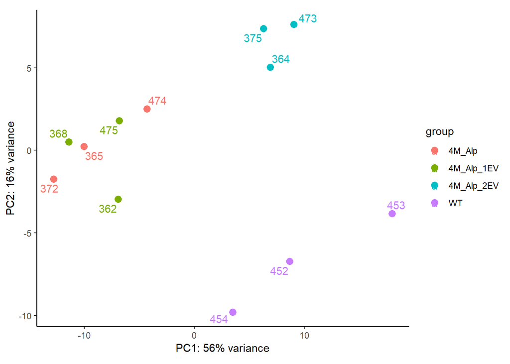

```r
group <-DESeq2::plotPCA(rld, ntop = 1000, intgroup = "Group") +
  geom_text_repel(aes(label = sample_names)) +
  coord_fixed(ratio = 1.5) +
  theme_classic()

plot(group)
```

### 6.1.3 No EVs

```r
# head(SO2@meta.data)

pbo <- AggregateExpression(SO2,
                           group.by = "sample",
                           assays = 'RNA',
                           slot = "counts",
                           return.seurat = FALSE)

pbo <- pbo$RNA
# pbo[1:5, 1:5]
colnames(pbo) <- sub("^g", "", colnames(pbo))
pbo <- pbo[, !colnames(pbo) %in% c("473", "375", "364", "368", "475", "362")]
#colnames(pbo)

# DimPlot(SO2, group.by = "sample")

metadata <- SO2@meta.data %>%
  as.data.frame() %>%
  dplyr::group_by(sample) %>%
  dplyr::summarise(
    Alports = names(sort(table(alports), decreasing = TRUE))[1],  # Most common value
    Batch = names(sort(table(batch), decreasing = TRUE))[1],
    Group = names(sort(table(group), decreasing = TRUE))[1]
  ) %>%
  as.data.frame()

metadata <- metadata %>%
  dplyr::filter(Group != "4M_Alp_1EV")

metadata <- metadata %>%
  dplyr::filter(Group != "4M_Alp_2EV")

rownames(metadata) <- metadata$sample

# head(metadata)

dds <- DESeqDataSetFromMatrix(countData = round(pbo),
                              colData = metadata,
                              design = ~ sample)

rld <- rlog(dds, blind=TRUE)

sample_names <- unique(rld$sample)
```

#### 6.1.3.1 PCA By **Sample**

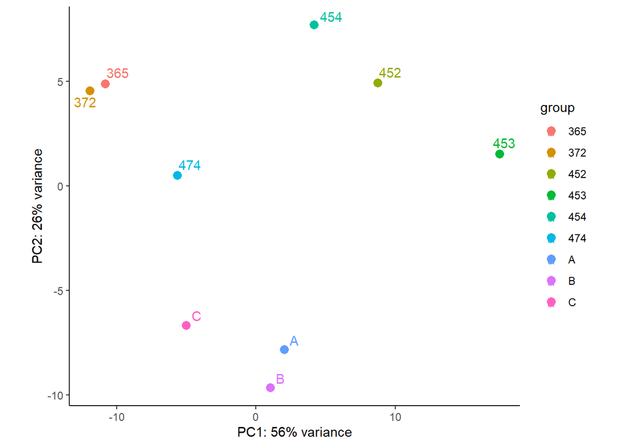

```r
# Plot PCA
sample<-DESeq2::plotPCA(rld, ntop = 1000, intgroup = "sample") +
  geom_text_repel(aes(label = sample_names)) +
  coord_fixed(ratio = 1.5) +
  theme_classic()

plot(sample)
```

#### 6.1.3.2 PCA By **Alports**

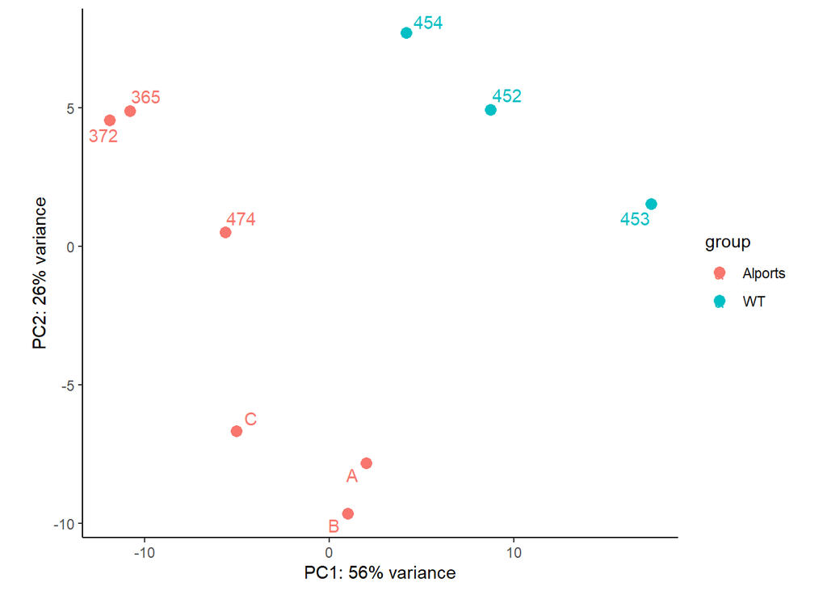

```r
alports <-DESeq2::plotPCA(rld, ntop = 1000, intgroup = "Alports") +
  geom_text_repel(aes(label = sample_names)) +
  coord_fixed(ratio = 1.5) +
  theme_classic()

plot(alports)
```

#### 6.1.3.3 PCA By **Group**

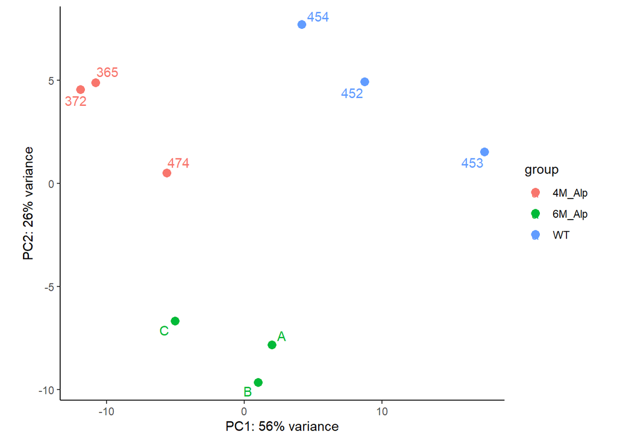

```r
group <-DESeq2::plotPCA(rld, ntop = 1000, intgroup = "Group") +
  geom_text_repel(aes(label = sample_names)) +
  coord_fixed(ratio = 1.5) +
  theme_classic()

plot(group)
```